# Goal

## When to drop or keep outliers?

> I believe that the dropping outlier is always a harsh step and should be taken only in extreme conditions when we’re very sure that the outlier is due to a measurement error, which we generally do not know while doing analysis.

> Sometimes outliers indicate a mistake in data collection. Other times, though, they can influence a data set, so it’s important to keep them to better understand the dataset in the big picture.

#### But let's try to remove the outliers from `SALE PRICE` column . And also You can do this in other columns too.

```python
# calculate Q1 and Q3
Q1 = df['SALE PRICE'].quantile(0.25)
Q3 = df['SALE PRICE'].quantile(0.75)

# calculate the IQR
IQR = Q3 - Q1
```

```python
df = df[ df['SALE PRICE'] < (Q3+1.5*IQR)]
df.shape
```

```
(206224, 19)
```

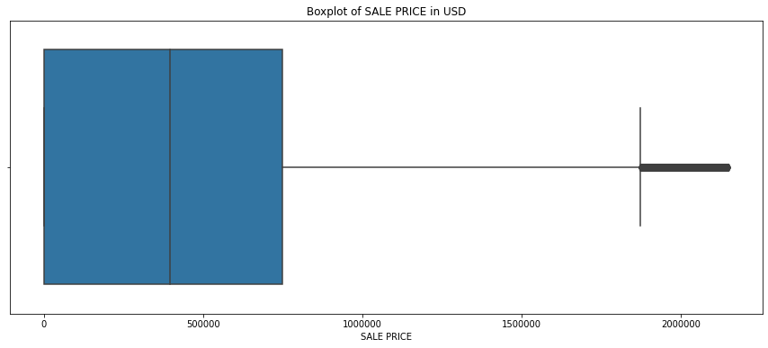

```python
#Set the size of the plot
plt.figure(figsize=(15,6))

# Plot the data and configure the settings
sns.boxplot(x='SALE PRICE', data=df)
plt.ticklabel_format(style='plain', axis='x')
plt.title('Boxplot of SALE PRICE in USD')
plt.show()
```

> As we can see , we get a new distribution of our variable with a new IQR. With the new IQR other values can be outliers that were not outliers with the IQR of the original variable (and therefore are not removed). Thus, you need to rerun the previous two cells again and again as long as there are outliers.

```python
df2 = df[(df['SALE PRICE'] > 100000) & (df['SALE PRICE'] < 5000000)]

df2.rename(columns = {"SALE PRICE":"sale_price"},inplace = True)

# For visualization purposes, we replace borough numbering with their string names.
df2['BOROUGH'] = df2['BOROUGH'].astype(str)
df2['BOROUGH'] = df2['BOROUGH'].str.replace('1.0', "Manhattan")
df2['BOROUGH'] = df2['BOROUGH'].str.replace('2.0', "Bronx")
df2['BOROUGH'] = df2['BOROUGH'].str.replace('3.0', "Brooklyn")
df2['BOROUGH'] = df2['BOROUGH'].str.replace('4.0', "Queens")
df2['BOROUGH'] = df2['BOROUGH'].str.replace('5.0', "Staten Island")

trace0 = go.Box(
    y=df2.sale_price[df2.BOROUGH == 'Manhattan' ],
    name = 'Manhattan',
    marker = dict(color = 'rgb(12, 12, 140)',))
trace1 = go.Box(
    y=df2.sale_price[df2.BOROUGH ==  'Bronx' ],
    name = 'Bronx',
    marker = dict(color = 'rgb(8,81,156)',))
trace2 = go.Box(
    y=df2.sale_price[df2.BOROUGH ==  'Brooklyn' ],
    name = 'Brooklyn',
    marker = dict(color = 'rgb(12, 12, 140)',))
trace3 = go.Box(
    y=df2.sale_price[df2.BOROUGH ==  'Queens' ],
    name = 'Queens',
    marker = dict(color = 'rgb(12, 128, 128)',))
trace4 = go.Box(
    y=df2.sale_price[df2.BOROUGH ==  'Staten Island' ],
    name = 'Staten Island',
    marker = dict(color = 'rgb(12, 12, 140)',))

dat = [trace0, trace1, trace2, trace3, trace4]
layout = go.Layout(
    title='Housing Prices by Boroughs',
    xaxis=dict(
        title='Borough'
    ),
    yaxis=dict(
        title='Sale Price'
    ),
    paper_bgcolor='rgb(243, 243, 243)',
    plot_bgcolor='rgb(243, 243, 243)'
)

fig = go.Figure(data=dat, layout=layout)
fig.show(renderer="colab")
```

[figure not shown]

[interactive chart not shown]

#### The next column is (`COMMERCIAL UNITS` & `RESIDENTIAL UNITS` & `TOTAL UNITS`)

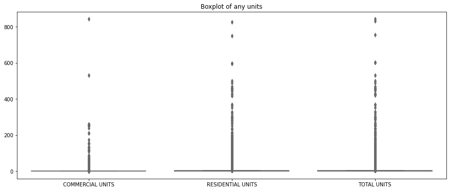

```python
#Set the size of the plot
plt.figure(figsize=(15,6))

df2 = df[['COMMERCIAL UNITS','RESIDENTIAL UNITS','TOTAL UNITS']]
df2.head()
# Plot the data and configure the settings
sns.boxplot(data=df2, palette="Set3")
plt.title('Boxplot of any units')
plt.show()
```

> I am deleting the outliers with very large numbers of `TOTAL UNITS` . Those are only a handful of observations though. In addition, I get rid of the observations the sum of `COMMERCIAL UNITS` and `RESIDENTIAL UNITS` doesn't match `TOTAL UNITS`.

```python
#Remove data where commercial + residential doesn't equal total units
df = df[df['TOTAL UNITS'] == df['COMMERCIAL UNITS'] + df['RESIDENTIAL UNITS']]
```

```python
len(df[df['TOTAL UNITS']>50.0])
# len(df[df['TOTAL UNITS']==0])
```

```
568
```

```python
# Only a handful of properties with more than 50 total units are remaining and they will now be deleted
df = df[df['TOTAL UNITS'] < 50]
```

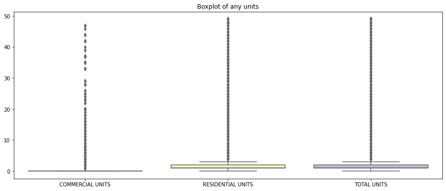

```python
#Set the size of the plot
plt.figure(figsize=(15,6))

df2 = df[['COMMERCIAL UNITS','RESIDENTIAL UNITS','TOTAL UNITS']]
df2.head()
# Plot the data and configure the settings
sns.boxplot(data=df2, palette="Set3")
plt.title('Boxplot of any units')
plt.show()
```

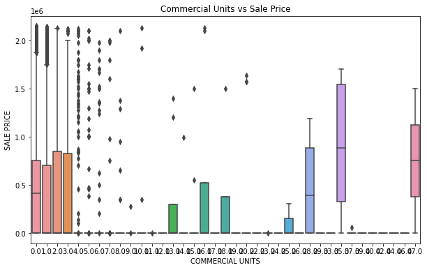

```python
plt.figure(figsize=(10,6))
sns.boxplot(x='COMMERCIAL UNITS', y='SALE PRICE', data=df)
plt.title('Commercial Units vs Sale Price')
plt.show()
```

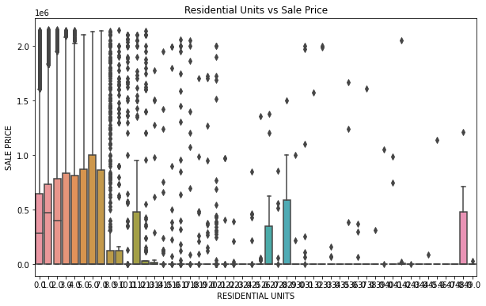

```python
plt.figure(figsize=(10,6))
sns.boxplot(x='RESIDENTIAL UNITS', y='SALE PRICE', data=df)
plt.title('Residential Units vs Sale Price')
plt.show()
```

#### The next column is (`YEAR BUILT`)

> However, YEAR BUILT isn't quite the variable we are looking for. What is more interesting is the BUILDING AGE. Both contain similar information, the second is however a bit more practical. So, let's create it.

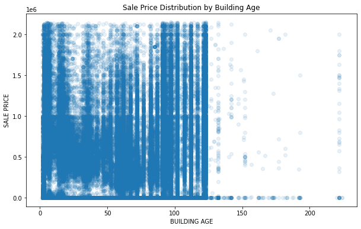

```python
df['BUILDING AGE'] = 2022 - df['YEAR BUILT']

plt.figure(figsize=(10,6))
sns.regplot(x='BUILDING AGE', y='SALE PRICE', data=df, fit_reg=False, scatter_kws={'alpha':0.1})
plt.title('Sale Price Distribution by Building Age')
plt.show()
```

#### The next column is (`BOROUGH`)

> This is all in good shape and no surpises here.

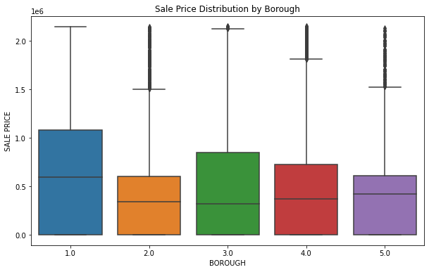

```python
plt.figure(figsize=(10,6))
sns.boxplot(x='BOROUGH', y='SALE PRICE', data=df)
plt.title('Sale Price Distribution by Borough')
plt.show()
```